# Introduction

This was a Kaggle competition a few years ago. Given some predictors/explanatory variables, we are helping Santander Bank to identify potential unhappy customers. This is a binary classification problem, where `0` indicates satisfied customer and `1` indicates unhappy customer. Predictions on the test set are evaluated based on area under the ROC curve.

```python
import pandas as pd
train = pd.read_csv("train.csv")
test = pd.read_csv("test.csv")
len(list(train))
```

```
371
```

```python
train["TARGET"].value_counts()
```

```
0    73012
1     3008
Name: TARGET, dtype: int64
```

We can see that among the 76020 training observations, only 3008 of them were unhappy customers. We may need to resort to stratification when we intend to split training and validation data.

# Data Processing

Since many python packages only read numeric input, it is a good idea to check that all predictor columns are numeric.

```python
list( set( train.columns ) - set( train._get_numeric_data().columns ) )
```

```
[]
```

Next, we also check that there are no missing data.

```python
train.columns[ train.shape[0] - train.count() != 0 ] # no missing training data
test.columns[ test.shape[0] - test.count() != 0 ] # no missing test data
```

```
Index([], dtype='object')
```

Before we do any further pre-processing, we remove the `ID` column.

```python
train.drop(["ID"], axis = 1, inplace = True)
test_ID = test["ID"] # we need test ID to write out result later
test.drop(["ID"], axis = 1, inplace = True)
```

It is also a good idea to remove columns in training data that only contains one unique value, since this does not provide any useful information in predicting customer satisfaction if every customer shares the same value. We also discard these same columns in test data, regardless whether the corresponding columns in test data actually have more than one unique value. Remember that we always have to be "blinded" from the test data.

```python
unique_num = train.apply(pd.Series.nunique)
cols_to_drop = unique_num[unique_num == 1].index
train.drop(cols_to_drop, axis=1, inplace = True)
test.drop(cols_to_drop, axis=1, inplace = True)
del unique_num, cols_to_drop
train.shape[1]
```

```
336
```

```python
train.drop_duplicates(inplace = True)
y_train = train["TARGET"]
train.drop("TARGET", axis = 1, inplace = True)
```

Now, we remove highly correlated (Pearson correlation $\geq$ 0.9) columns in the training data.

```python
import numpy as np
cor_thresh = 0.9
corr_matrix = train.corr().abs()
upper = corr_matrix.where(np.triu(np.ones(corr_matrix.shape), k=1).astype(np.bool))
to_drop = [col for col in upper.columns if any(upper[col] > cor_thresh)]
train.drop(train[to_drop], axis=1, inplace = True)
del corr_matrix, upper, cor_thresh
```

Of course we took the easy way of using Pearson correlation for all columns, regardless if some columns may actually correspond to categorical variables -- columns with two to (perhaps) five unique values. To assess association among categorical variables, we can use chi-square test of independence. For example, for 2 categorical variables $U$ and $V$, we test

$H_0$: $U$ and $V$ are independent.  
$H_1$: $U$ and $V$ are dependent.

We could choose to drop either $U$ or $V$ (but not both!) if the p-value is very small, perhaps say, 0.01. Similarly, we could use Kruskal-Wallis test to assess association between a categorical variable and a continuous variable.

We also remove the corresponding columns in the test set.

```python
test.drop(test[to_drop], axis=1, inplace = True)
del to_drop
```

Finally, we standardize the columns in training data. We use the corresponding column means and standard deviations to scale the corresponding columns in test data. Again, remember that we have to be "blinded" from the test set.

```python
mean = train.mean(axis = 0) # return a vector of column (axis = 0) means
stdev = train.std(axis = 0) # return a vector of column (axis = 0) std dev
train -= mean
train /= stdev
test -= mean
test /= stdev
del mean, stdev
```

Of course we are a bit "lazy" above, as we treat the predictors as if they are all continuous. A better approach would be to standardize only those continuous predictors, and one-hot encode the categorical variables.

Now we are ready to train some models.

# Random Forest

There are several tuning parameters to decide on. We would use the default `max_features`, ie. to grow each tree, we would use only $\sqrt{p} = \sqrt{169} = 13$ variables sampled randomly out of the 169 predictors. We could use grid-search with 3-fold cross validation to decide the number of trees in the forest (`n_estimators`) as well as the depth of each tree (indirectly) controlled by the minimum number of observations in each terminal node (`min_samples_leaf`). Recall that we could afford to build huge trees -- which leads to low bias and high variance -- in the forest (at the expense of heavier computation), since averaging across multiple trees (decorrelated due to `max_features` smaller than number of predictors) helps to bring down variance. Since this is a binary classification, we could use gini index as the criterion for our random forest model. The different random forest models (based on different combinations of `n_estimators` and `min_samples_leaf`) are compared using area under the ROC curve (`roc_auc`).

```python
from sklearn.ensemble import RandomForestClassifier
from sklearn.metrics import roc_auc_score
from sklearn.model_selection import GridSearchCV

train = train.to_numpy()
y_train = y_train.to_numpy(dtype = "float32")
test = test.to_numpy()

rf_mod = RandomForestClassifier(criterion = "gini",
                                random_state = 42,
                                max_features = "auto",
                                bootstrap = True)

params = {
    'n_estimators': [1000, 2000, 3000], # default 100
    'min_samples_leaf': [3, 5, 10] # default 1
 }

grid_search = GridSearchCV(rf_mod,
                           param_grid = params,
                           scoring = "roc_auc",
                           n_jobs = 2,
                           refit = True,
                           cv = 3,
                           verbose = 3,
                           return_train_score = False)

grid_search.fit(train, y_train)
grid_search.best_estimator_
grid_search.best_score_
```

The Random Forest grid search with 3-fold CV codes above take time to run. The best model built 3000 trees in the forest (`n_estimators` = 3000) with a minimum of 5 observations for each leaf in the trees (`min_samples_leaf` = 5). The best model has an AUC score of 0.82765.

Alternatively, we could use the training set's OOB (out-of-bag) accuracy score as a criterion to pick the best model without doing cross-validation. Note that our OOB score may still be higher than the test score (ie. OOB score does not generalize ideally) since OOB only involves roughly one third of the training set, whereas the test set in this competition is about the same size as the training set.

```python
from itertools import product
params_arr = np.array( list( product( *params.values() ) ) )
rf_OOB = []
for prm in params_arr:
     rf_mod = RandomForestClassifier(criterion = "gini",
                                random_state = 42,
                                max_features = "auto",
                                oob_score = True,
                                n_estimators = prm[0],
                                min_samples_leaf = prm[1],
                                bootstrap = True)
     rf_mod.fit(train, y_train)
     rf_OOB.append(rf_mod.oob_score_)
params_arr[ rf_OOB.index( max(rf_OOB) ) ]
```

We use the best model to predict the test set.

```python
test_pred = grid_search.predict_proba(test)
test_pred = test_pred[ : , 1]
res = pd.concat( [ test_ID, pd.Series( test_pred ) ], axis = 1)
res.columns = ["ID", "TARGET"]
res.to_csv('rf_try1.csv', header = True, index = False)
```

The test set AUC public score using this random forest model is 0.82503, which is pretty close to our training set AUC score.

# Neural Network

Recall that there are far fewer cases of unhappy customers than satisfied customers in the training set. Hence we use stratified sampling to set aside a validation set.

```python
train = pd.concat( [train, y_train], axis = 1)
from sklearn.model_selection import StratifiedShuffleSplit

## StratifiedShuffleSplit.split generate training and test set indices
split = StratifiedShuffleSplit(n_splits = 1,
                               test_size = 0.2,
                               random_state = 42)
for train_ind, val_ind in split.split(train, train["TARGET"]):
    strat_train = train.iloc[train_ind]
    strat_val = train.iloc[val_ind]

train.drop("TARGET", axis = 1, inplace = True)
y_strat_train = strat_train["TARGET"].copy().to_numpy(dtype="float32")
y_strat_val = strat_val["TARGET"].copy().to_numpy(dtype="float32")
strat_train = strat_train.to_numpy()
strat_val = strat_val.to_numpy()
strat_train = np.delete(strat_train, -1, axis=1)
strat_val = np.delete(strat_val, -1, axis=1)

import gc
gc.collect()
```

```
92
```

There are various research on how to specify the network architectures. For starters, we would use the most common choices:

- (hidden layer) activation function: relu (rectified linear unit)
- output layer activation: sigmoid
- optimizer: rmsprop
- metrics: `accuracy`
- loss function: `binary_crossentropy` since we are dealing with binary classification

For network architecture, we first try a shallow network: 1 hidden layers with 512 nodes. We then train our neural network for different number of epochs and assess their `accuracy` based on the validation set.

```python
from keras import models
from keras import layers
from keras.optimizers import RMSprop, adam

mod = models.Sequential()
mod.add( layers.Dense( 512, activation = 'relu',
                       input_shape = (strat_train.shape[1],) ) )
mod.add( layers.Dense( 1, activation = 'sigmoid' ) )
mod.compile(optimizer = 'rmsprop',
            loss = 'binary_crossentropy',
            metrics = ['accuracy'])

hist = mod.fit(x = strat_train,
               y = y_strat_train,
               epochs = 15,
               batch_size = 1024,
               validation_data = (strat_val, y_strat_val))

hist_dict = hist.history #history object
loss_val = hist_dict['loss']
validate_loss_val = hist_dict['val_loss']
```

We then plot the training and validation losses and accuracies across the different epochs.

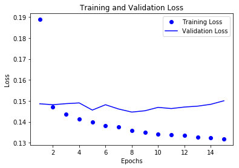

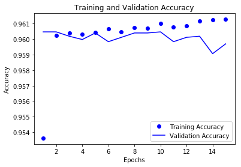

```python
epochs = range(1, len(hist_dict['acc']) + 1)

import matplotlib.pyplot as plt
%config InlineBackend.close_figures=True # keep figures open in pyplot
plt.clf() # CLEAR previous figures!!!

plt.plot(epochs,
         loss_val,
         'bo', # blue dot
          label = 'Training Loss')
plt.plot(epochs,
         validate_loss_val,
         'b', # blue solid line
         label = 'Validation Loss')
plt.title('Training and Validation Loss')
plt.xlabel('Epochs')
plt.ylabel('Loss')
plt.legend()
plt.show()

plt.clf() # CLEAR previous figures!!!
acc_val = hist_dict['acc']
validate_acc_val = hist_dict['val_acc']

plt.plot(epochs,
         acc_val,
         'bo', # blue dot
         label = 'Training Accuracy')
plt.plot(epochs,
         validate_acc_val,
         'b', # blue solid line
         label = 'Validation Accuracy')
plt.title('Training and Validation Accuracy')
plt.xlabel('Epochs')
plt.ylabel('Accuracy')
plt.legend()
plt.show()
```

From the plots above, it appears that 5 epochs are sufficient. We proceed to train our neural network model and fit the test data.

```python
mod = models.Sequential()
mod.add( layers.Dense( 512, activation = 'relu',
                       input_shape = (strat_train.shape[1],) ) )
mod.add( layers.Dense( 1, activation = 'sigmoid' ) )
mod.compile(optimizer = 'rmsprop',
            loss = 'binary_crossentropy',
            metrics = ['accuracy'])

mod.fit(train.to_numpy(), np.asarray(y_train).astype('float32'),
        epochs = 5, batch_size = 1024)

from sklearn.metrics import roc_auc_score
train_pred = mod.predict(train.to_numpy())
roc_auc_score(np.asarray(y_train).astype('float32'), train_pred)

test_pred = mod.predict(test.to_numpy())
res = pd.concat( [ test_ID,
                  pd.Series( test_pred.reshape(test_pred.shape[0]) ) ],
      axis = 1)
res.columns = ["ID", "TARGET"]
res.to_csv('nn_try.csv', header = True, index = False)
```

The test set AUC public score using this shallow network is 0.81953.

# Support Vector Machine (SVM)

We would also try SVM. Apaprently the fit time for support vector classifier scales at least quadratically with the number of samples and may be impractical for us since we have 70k++ training samples. Instead, for starters, we shall only assume linear kernel and use `linearSVC` instead. We would again rely on grid search with 3-fold cross-validation to determine a suitable value for violation cost `C`.

```python
train = train.to_numpy()
y_train = y_train.to_numpy(dtype = "float32")
test = test.to_numpy()

from sklearn.svm import LinearSVC
from sklearn.metrics import roc_auc_score
from sklearn.model_selection import GridSearchCV
from sklearn.calibration import CalibratedClassifierCV

svm_mod = LinearSVC(random_state = 42, max_iter = 10000, tol = 0.001)

params = {'C': [1, 5, 10, 50, 100]}

grid_search = GridSearchCV(svm_mod,
                           param_grid = params,
                           scoring = "accuracy",
                           n_jobs = 2,
                           refit = True,
                           cv = 3,
                           verbose = 3,
                           return_train_score = False)

grid_search.fit(train, y_train)
grid_search.best_estimator_
grid_search.best_score_
```

It turns out that `C` = 1 is our best model. We also need to take note the fact that SVM is a hard classifier, and no predicted probability is provided for the test cases, which is required to make submisssion to the competition. We will instead rely on probability calibration.

```python
CCcv = CalibratedClassifierCV( base_estimator = LinearSVC(C = 1,
                                                          dual=False,
                                                          max_iter = 10000,
                                                          tol = 0.001),
                               method = 'isotonic', cv = 5)
CCcv.fit(train, y_train)
test_pred = CCcv.predict_proba(test)[ : , 1]
res = pd.concat( [ test_ID,
                  pd.Series( test_pred.reshape(test_pred.shape[0]) ) ],
      axis = 1)
res.columns = ["ID", "TARGET"]
res.to_csv('svm_try1.csv', header = True, index = False)
```

The test set AUC public score using linear support vector classifier is 0.79904.

# Extreme Gradient Boosting

Finally, we adopt gradient boosting using the Xgboost(extreme gradient boosting) implementation -- an algorithm that has gained popularity in recent kaggle competitions. Briefly, the existing classifier is iteratively updated to capture pseudo-residuals (negative gradient) that has not been accounted for in previous iterations.

```python
# Extreme Gradient Boosting
from xgboost import XGBClassifier
from scipy.stats import uniform, randint
from sklearn.metrics import roc_auc_score
from sklearn.model_selection import RandomizedSearchCV

train = train.to_numpy()
y_train = y_train.to_numpy(dtype = "float32")
test = test.to_numpy()

xgb_mod = XGBClassifier(objective="binary:logistic",
                        booster='gbtree',
                        random_state=42,
                        eval_metric="auc")

params = {
    "gamma": uniform(0, 0.3), # default 0
    "learning_rate": uniform(0.1, 0.25), # default 0.3
    "max_depth": randint(1, 4), # default 6
    "n_estimators": randint(100, 1000) # default 100
}

rand_search = RandomizedSearchCV(xgb_mod,
                                 param_distributions = params,
                                 # scoring = "roc_auc",
                                 random_state = 42,
                                 n_iter = 40, # Number of parameter settings that are sampled
                                 cv = 3,
                                 verbose = 1,
                                 n_jobs = 2,
                                 refit = True,
                                 return_train_score = False)
rand_search.fit(train, y_train)
rand_search.best_estimator_
rand_search.best_score_
```

```python
test_pred = rand_search.predict_proba(test)
test_pred = test_pred[ : , 1]
res = pd.concat( [ test_ID, pd.Series( test_pred ) ], axis = 1)
res.columns = ["ID", "TARGET"]
res.to_csv('xgboost_try2.csv', header = True, index = False)
```

The test set AUC public score using this extreme gradient boosting model is 0.83379.